# Linage-specific motifs by the UpSetR. We find Enh DAR DMRs intersection of motifs within each Layer: show how similar motifs are for regions of the same lineage, and how different they are between lineages

-We are checking if Enh DAR DMR motifs are lineage-specific within laeyr, e.g. contain mostly different between each other motifs and most similar within any Layer

```r
library(tidyverse)
library(ggplot2)
library(gridExtra)
library(tidyr)
library(ggpubr)
library("readxl")
library(datasets)
library(UpSetR)
library(VennDiagram)
library(repurrrsive) #for list length
```

-read motifs Excel files: Enhancers, DMRs, DARs

-read motifs Enhancers

```r
#-----------------Enhancers weis

#read_excel("C:/Users/ia1/Documents/irina_docs/EpiGeVar/MayJune2020_egv/DARs_Carine/wei_ecto.xlsx")->motifs_EnhancerEc1
#motifs_EnhancerEc1

read_excel("data_motifs_Carine/wei_ecto.xlsx")->motifs_EnhancerEc1
motifs_EnhancerEc1
```

| TF | P | logP | q-Ben | #Tar_Motif | percTar_Motif | #bg_Motif | perc_bg_Motif |
| --- | --- | --- | --- | --- | --- | --- | --- |
| OCT4-SOX2-TCF-NANOG(POU,Homeobox,HMG)/mES-Oct4-ChIP-Seq(GSE11431)/Homer | 1e-25 | -59.30 | 0.0000 | 62 | 0.2138 | 2018.5 | 0.0414 |
| Sox2(HMG)/mES-Sox2-ChIP-Seq(GSE11431)/Homer | 1e-13 | -31.70 | 0.0000 | 116 | 0.4000 | 9925.0 | 0.2035 |
| Sox4(HMG)/proB-Sox4-ChIP-Seq(GSE50066)/Homer | 1e-12 | -28.00 | 0.0000 | 109 | 0.3759 | 9511.2 | 0.1950 |
| Sox21(HMG)/ESC-SOX21-ChIP-Seq(GSE110505)/Homer | 1e-12 | -28.00 | 0.0000 | 181 | 0.6241 | 20276.8 | 0.4157 |
| Sox3(HMG)/NPC-Sox3-ChIP-Seq(GSE33059)/Homer | 1e-10 | -25.20 | 0.0000 | 167 | 0.5759 | 18543.1 | 0.3802 |
| Sox17(HMG)/Endoderm-Sox17-ChIP-Seq(GSE61475)/Homer | 1e-09 | -21.60 | 0.0000 | 87 | 0.3000 | 7577.3 | 0.1553 |
| Sox6(HMG)/Myotubes-Sox6-ChIP-Seq(GSE32627)/Homer | 1e-09 | -20.90 | 0.0000 | 150 | 0.5172 | 16732.1 | 0.3430 |
| Oct4(POU,Homeobox)/mES-Oct4-ChIP-Seq(GSE11431)/Homer | 1e-08 | -20.40 | 0.0000 | 62 | 0.2138 | 4662.8 | 0.0956 |
| Sox10(HMG)/SciaticNerve-Sox3-ChIP-Seq(GSE35132)/Homer | 1e-08 | -20.00 | 0.0000 | 154 | 0.5310 | 17559.0 | 0.3600 |
| Sox7(HMG)/ESC-Sox7-ChIP-Seq(GSE133899)/Homer | 1e-08 | -19.00 | 0.0000 | 47 | 0.1621 | 3134.0 | 0.0643 |

[output cut: 34 more lines]

```r
read_excel("data_motifs_Carine/wei_endo.xlsx")->motifs_EnhancerEn1
#motifs_EnhancerMes1

read_excel("data_motifs_Carine/wei_meso.xlsx")->motifs_EnhancerMes1
#motifs_EnhancerMes1
```

-read motifs in DMRs

```r
#-----------------DMRs

read_excel("data_motifs_Carine/wei_ecto.xlsx")->motifs_DMREc1
#motifs_DMRMes1

read_excel("data_motifs_Carine/wei_endo.xlsx")->motifs_DMREn1
#motifs_DMRMes1

read_excel("data_motifs_Carine/wei_meso.xlsx")->motifs_DMRMes1
#motifs_DMRMes1
```

-read motifs in DARs

```r
read_excel("data_motifs_Carine/DAR_ecto.xlsx")->motifs_DAREc1

read_excel("data_motifs_Carine/DAR_endo.xlsx")->motifs_DAREn1
#motifs_DARMes


read_excel("data_motifs_Carine/DAR_meso.xlsx")->motifs_DARMes1
#motifs_DARMes1
```

-B. set quantile thresholds for each Layer regions

-B.DMR quantiles DMR

```r
quantile(motifs_DMREc1$P)->q_dmr_ec
quantile(motifs_DMREn1$P)->q_dmr_en
quantile(motifs_DMRMes1$P)->q_dmr_m
q_dmr_ec
```

```
      0%      25%      50%      75%     100%
1.00e-25 7.75e-08 1.00e-04 1.00e-02 1.00e-02
```

```r
q_dmr_en
```

```
   0%   25%   50%   75%  100%
1e-51 1e-13 1e-03 1e-02 1e-02
```

```r
q_dmr_m
```

```
   0%   25%   50%   75%  100%
1e-17 1e-07 1e-05 1e-03 1e-02
```

-set thr DMR, quantiles Q75%

```r
thrPe_ec2<-q_dmr_ec[4]
thrPe_en2<-q_dmr_en[3]# to make a little smaller
thrPe_m2<-q_dmr_m[4]
```

-make individual motif lists for DMRs: get the functions first

```r
source("make_filterP_list_dmrEc.R")
source("make_filterP_list_dmrEn.R")
source("make_filterP_list_dmrM.R")
```

- upsetR plot DMRs -how similar dmr motifs are bw layers, thrP quantile

```r
#-----------------------Q75 thr

vdmrec2<-make_filterP_list_dmrEc(motifs_DMREc1,thrPe_ec2)
#library(repurrrsive)
vdmrec2%>%
map(length)
```

```
$motifs_DMREc
[1] 44
```

```r
#typeof(vdmrec)

vdmren2<-make_filterP_list_dmrEn(motifs_DMREn1,thrPe_en2)
vdmren2%>%
map(length)
```

```
$motifs_DMREn
[1] 75
```

```r
vdmrm2<-make_filterP_list_dmrM(motifs_DMRMes1,thrPe_m2)
vdmrm2%>%
map(length)
```

```
$motifs_DMRM
[1] 43
```

- upsetR plot DMRs -how similar dmr motifs are bw layers, thrP quantile

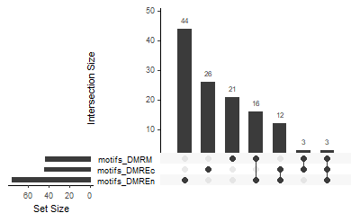

```r
listik_dmr_EcEnM2=c(vdmrec2,vdmren2,vdmrm2)
upset(fromList(listik_dmr_EcEnM2),empty.intersections = "on")
```

```r
#----------list of motifs
#vdmrec2
#vdmren2
```

-B.DAR quantiles DAR

```r
quantile(motifs_DAREc1$P)->q_dar_ec
quantile(motifs_DAREn1$P)->q_dar_en
quantile(motifs_DARMes1$P)->q_dar_m
q_dar_ec
```

```
   0%   25%   50%   75%  100%
1e-90 1e-10 1e-05 1e-03 1e-02
```

```r
q_dar_en
```

```
   0%   25%   50%   75%  100%
1e-84 1e-17 1e-06 1e-03 1e-02
```

```r
q_dar_m
```

```
   0%   25%   50%   75%  100%
1e-49 1e-13 1e-05 1e-03 1e-02
```

-set thr DAR, quantiles Q25%

```r
thrPe_ec2<-q_dar_ec[2]
thrPe_en2<-q_dar_en[2]# to make a little smaller
thrPe_m2<-q_dar_m[2]
```

-make individual lists for DARs: get the functions

```r
source("make_filterP_list_darEc.R")
source("make_filterP_list_darEn.R")
source("make_filterP_list_darM.R")
```

- upsetR plot DARs -how similar dmr motifs are bw layers, thrP quantile

```r
#-----------------------Q75 thr

vdarec2<-make_filterP_list_darEc(motifs_DAREc1,thrPe_ec2)
#library(repurrrsive)
vdarec2%>%
map(length)
```

```
$motifs_DAREc
[1] 46
```

```r
#typeof(vdarec)

vdaren2<-make_filterP_list_darEn(motifs_DAREn1,thrPe_en2)
vdaren2%>%
map(length)
```

```
$motifs_DAREn
[1] 53
```

```r
vdarm2<-make_filterP_list_darM(motifs_DARMes1,thrPe_m2)
vdarm2%>%
map(length)
```

```
$motifs_DARM
[1] 48
```

- upsetR plot DARs -how similar dar motifs are bw layers, thrP quantile

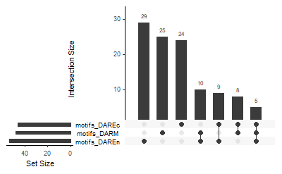

```r
#---------------------should be different mostly
listik_dar_EcEnM2=c(vdarec2,vdaren2,vdarm2)
upset(fromList(listik_dar_EcEnM2),empty.intersections = "on")
```

-B.Wei Enhancers

-quantiles Wei

```r
quantile(motifs_EnhancerEc1$P)->q_w_ec
quantile(motifs_EnhancerEn1$P)->q_w_en
quantile(motifs_EnhancerMes1$P)->q_w_m
q_w_ec
```

```
      0%      25%      50%      75%     100%
1.00e-25 7.75e-08 1.00e-04 1.00e-02 1.00e-02
```

```r
q_w_en
```

```
   0%   25%   50%   75%  100%
1e-51 1e-13 1e-03 1e-02 1e-02
```

```r
q_w_m
```

```
   0%   25%   50%   75%  100%
1e-17 1e-07 1e-05 1e-03 1e-02
```

- change thr, quantiles Q75% Wei

```r
thrPe_ec2<-q_w_ec[4]
thrPe_en2<-q_w_en[3]# to make a little smaller
thrPe_m2<-q_w_m[4]
```

-make ind lists for Enhancers Wei

```r
source("make_filterP_list_enhEc.R")
source("make_filterP_list_enhEn.R")
source("make_filterP_list_enhM.R")
```

-quntile P-threshold Wei

```r
#-----------------------Q75 thr Wei

vwec2<-make_filterP_list_enhEc(motifs_EnhancerEc1,thrPe_ec2)
#library(repurrrsive)
vwec2%>%
map(length)
```

```
$motifs_EnhancerEc
[1] 44
```

```r
#typeof(vwec)

vwen2<-make_filterP_list_enhEn(motifs_EnhancerEn1,thrPe_en2)
vwen2%>%
map(length)
```

```
$motifs_EnhancerEn
[1] 75
```

```r
vwm2<-make_filterP_list_enhM(motifs_EnhancerMes1,thrPe_m2)
vwm2%>%
map(length)
```

```
$motifs_EnhancerM
[1] 43
```

-Ectoderm: Enh DAR DMR regions

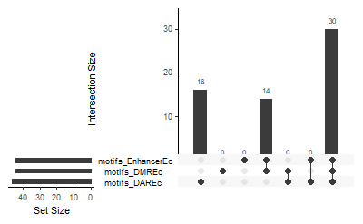

```r
listik_w_dar_dmr_Ec2=c(vwec2,vdarec2,vdmrec2)
upset(fromList(listik_w_dar_dmr_Ec2),empty.intersections = "on")
```

-get elements Ectoderm

```r
overlapEct<-calculate.overlap(listik_w_dar_dmr_Ec2)
#overlapEct
```

-Mesoderm: intersection of Enh DAR DMR

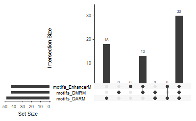

```r
listik_w_dar_dmr_M2=c(vwm2,vdarm2,vdmrm2)
upset(fromList(listik_w_dar_dmr_M2),empty.intersections = "on")
```

-get upset elements Mesoderm: inresect, distinct, paiwise

```r
overlapMes<-calculate.overlap(listik_w_dar_dmr_M2)
#overlapMes
```

-Endoderm within: intersection of Enh DAR DMR

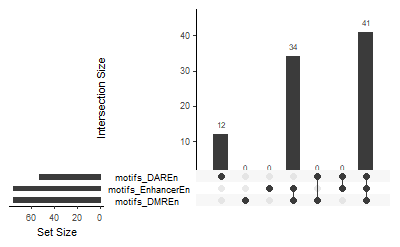

```r
listik_w_dar_dmr_En2=c(vwen2,vdaren2,vdmren2)
upset(fromList(listik_w_dar_dmr_En2),empty.intersections = "on")
```

-get elements Endoderm

```r
overlapEnd<-calculate.overlap(listik_w_dar_dmr_En2)
#overlapEnd
```